# Simple Data exploration airbnb dataset in Lisbon from JULY 2019

Authors: Ricardo Clemente

Contact: ricardomiguelrosaclemente@gmail.com

Github: https://github.com/ric-clemente

# Contents

- 1. Loading libraries and loading data
  - 1.1 Loading libraries
  - 1.2 Loading Data
- 2. Data exploration by Neighbourhood
  - 2.1 Frequency
  - 2.2 Price Average
  - 2.3 Room types
  - 2.4 Review Rating Average
  - 2.5 Average Prices in the future
  - 2.6 Prices vs Review Ratings
  - 2.7 Find the best Neighbourhood

# 1. Loading libraries and data

## 1.1 Loading libraries

```r
## Importing packages

# This R environment comes with all of CRAN and many other helpful packages preinstalled.
# You can see which packages are installed by checking out the kaggle/rstats docker image:
# https://github.com/kaggle/docker-rstats

library(tidyverse) # metapackage with lots of helpful functions
library(dplyr) #summarize dat
library(ggplot2)
library(sqldf)
#library(ggpubr)

## Running code

# In a notebook, you can run a single code cell by clicking in the cell and then hitting
# the blue arrow to the left, or by clicking in the cell and pressing Shift+Enter. In a script,
# you can run code by highlighting the code you want to run and then clicking the blue arrow
# at the bottom of this window.

## Reading in files

# You can access files from datasets you've added to this kernel in the "../input/" directory.
# You can see the files added to this kernel by running the code below.

list.files(path = "../input")

## Saving data

# If you save any files or images, these will be put in the "output" directory. You
# can see the output directory by committing and running your kernel (using the
# Commit & Run button) and then checking out the compiled version of your kernel.
```

'lisboa-airbnb-data'

## 1.2 Loading data

```r
#load datasets
listings<-read.csv("../input/lisboa-airbnb-data/listings.csv")
listings_details<-read.csv("../input/lisboa-airbnb-data/listings_details.csv")
calendar<-read.csv("../input/lisboa-airbnb-data/calendar.csv")
```

```r
#merge datasets and select just the colunms the are going to be used
listings_df<-cbind(listings,listings_details[,c("property_type","accommodates", "first_review", "review_scores_value", "review_scores_cleanliness", "review_scores_location", "review_scores_accuracy", "review_scores_communication", "review_scores_checkin", "review_scores_rating", "maximum_nights", "listing_url", "host_is_superhost", "host_about", "host_response_time", "host_response_rate", "street", "weekly_price", "monthly_price", "market")])
```

```r
#show some values from the datasets merged
head(listings_df)
```

A data.frame: 6 × 36

|  | id <int> | name <fct> | host_id <int> | host_name <fct> | neighbourhood_group <fct> | neighbourhood <fct> | latitude <dbl> | longitude <dbl> | room_type <fct> | price <int> | ⋯ | maximum_nights <int> | listing_url <fct> | host_is_superhost <fct> | host_about <fct> | host_response_time <fct> | host_response_rate <fct> | street <fct> | weekly_price <fct> | monthly_price <fct> | market <fct> |
| --- | --- | --- | --- | --- | --- | --- | --- | --- | --- | --- | --- | --- | --- | --- | --- | --- | --- | --- | --- | --- | --- |
| 1 | 6499 | Belém 1 Bedroom Historical Apartment | 14455 | Bruno | Lisboa | Belm | 38.69675 | -9.19840 | Entire home/apt | 36 | ⋯ | 365 | https://www.airbnb.com/rooms/6499 | f | I am Bruno Luis, a Portuguese living in The Hague and I work in IT. | within an hour | 100% | Lisbon, Lisbon, Portugal | $209.00 | $579.00 | Lisbon |
| 2 | 25659 | Sunny, Alfama Sleeps 3 - Coeur d'Alfama | 107347 | Ellie | Lisboa | Santa Maria Maior | 38.71167 | -9.12696 | Entire home/apt | 60 | ⋯ | 21 | https://www.airbnb.com/rooms/25659 | t | Artist | within an hour | 100% | Lisboa, Lisboa, Portugal | $350.00 |  | Lisbon |
| 3 | 28066 | ear the birds | 120855 | Lucia | Azambuja | Aveiras de Cima | 39.14654 | -8.91503 | Private room | 53 | ⋯ | 730 | https://www.airbnb.com/rooms/28066 | f |  | N/A | N/A | Azambuja, Portugal |  |  | Other (International) |
| 4 | 29138 | Room for rent in shared house | 125304 | Susana | Lisboa | Areeiro | 38.73634 | -9.13792 | Private room | 71 | ⋯ | 730 | https://www.airbnb.com/rooms/29138 | f |  | N/A | N/A | Lisbon, Lisbon, Portugal |  |  | Lisbon |
| 5 | 29248 | Apartamento Alfama com vista para o rio! | 125768 | Bárbara | Lisboa | Santa Maria Maior | 38.71272 | -9.12628 | Entire home/apt | 60 | ⋯ | 365 | https://www.airbnb.com/rooms/29248 | f | Hi! I'm a marketeer working for a sustainable world. I love to travel and learn with people and cultures. I've been traveling for 6 months around 20 countries between Israel and Cambodja informally st… | within a few hours | 100% | Lisbon, Lisbon, Portugal | $299.00 | $966.00 | Lisbon |
| 6 | 29396 | Alfama Hill - Boutique apartment | 126415 | Mónica | Lisboa | Santa Maria Maior | 38.71239 | -9.12887 | Entire home/apt | 60 | ⋯ | 30 | https://www.airbnb.com/rooms/29396 | t | Pretty apartment with a terrific view combined with a friendly and helpful host. | within an hour | 100% | Lisbon, Lisbon, Portugal | $310.00 | $1,199.00 | Lisbon |

# 2. Data exploration by Neighbourhood

## 2.1 Frequency

Calculate the frequency of listings by neighbourhood

A tibble: 6 × 2

| neighbourhood_group <fct> | counts <int> |
| --- | --- |
| Alenquer | 71 |
| Amadora | 137 |
| Arruda Dos Vinhos | 7 |
| Azambuja | 19 |
| Cadaval | 57 |
| Cascais | 2195 |

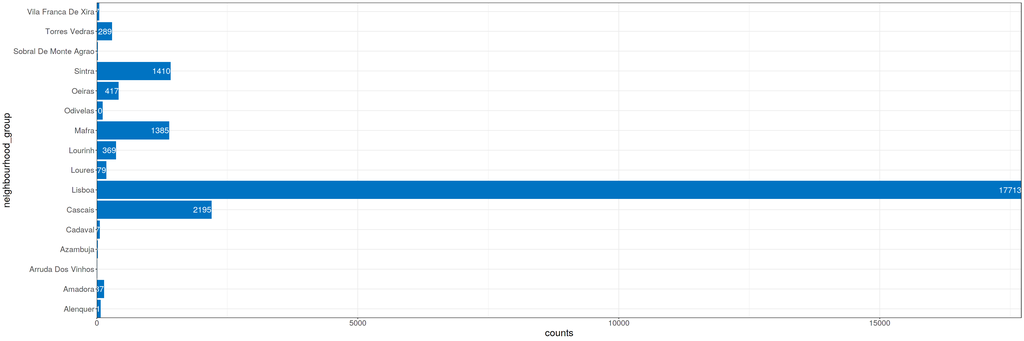

```r
#compute frequency
Neighbourhood_group_freq <- listings_df %>%
  group_by(neighbourhood_group) %>%
  summarise(counts = n())

#Show results
head(Neighbourhood_group_freq)


#plot results
options(repr.plot.width = 30, repr.plot.height = 10)


ggplot(Neighbourhood_group_freq, aes(x = neighbourhood_group, y = counts)) +
  geom_col(fill = "#0073C2FF",stat="dodge") +
  geom_bar(stat="identity",position = "fill")+
  geom_text(aes(label=counts), hjust=1, color="white", size=6)+

  coord_flip(expand=FALSE) +

  theme_bw()+
  theme(text = element_text(size=20))
```

## 2.2 Price Average

Calculate the price average by neighbourhood

A tibble: 6 × 2

| neighbourhood_group <fct> | avg_price <dbl> |
| --- | --- |
| Alenquer | 58.60870 |
| Amadora | 186.21277 |
| Arruda Dos Vinhos | 60.00000 |
| Azambuja | 45.33333 |
| Cadaval | 80.80952 |
| Cascais | 73.86932 |

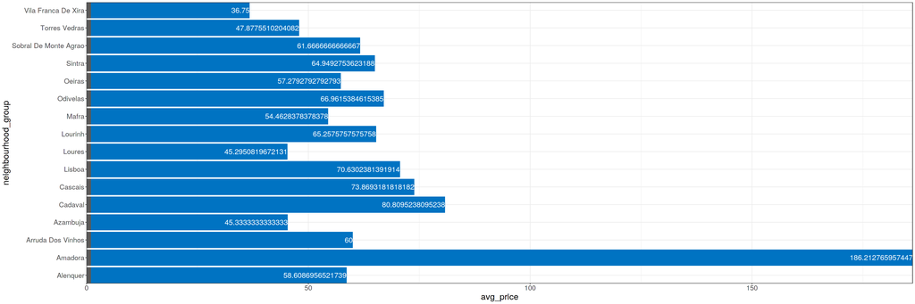

```r
#Calculate price average
Neighbourhood_group_price_avg <- listings_df %>%
  filter(accommodates==2) %>%
  group_by(neighbourhood_group) %>%
  summarise(avg_price = mean(price,na.rm=TRUE))

head(Neighbourhood_group_price_avg)


options(repr.plot.width = 30, repr.plot.height = 10)


ggplot(Neighbourhood_group_price_avg, aes(x = neighbourhood_group, y = avg_price)) +
  geom_col(fill = "#0073C2FF",stat="dodge") +
  geom_bar(stat="identity",position = "fill")+
  geom_text(aes(label=avg_price), hjust=1, color="white", size=6)+
  coord_flip(expand=FALSE) +

  theme_bw()+
  theme(text = element_text(size=20))
```

## 2.3 Room types

Check the Room types more frequently booked

A tibble: 3 × 2

| room_type <fct> | counts <int> |
| --- | --- |
| Entire home/apt | 18047 |
| Private room | 5958 |
| Shared room | 418 |

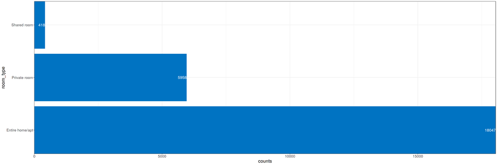

```r
Neighbourhood_group_type_freq <- listings_df %>%
  group_by(room_type) %>%
  summarise(counts = n())

head(Neighbourhood_group_type_freq)


options(repr.plot.width = 30, repr.plot.height = 10)


ggplot(Neighbourhood_group_type_freq, aes(x = room_type, y = counts)) +
  geom_col(fill = "#0073C2FF",stat="dodge") +
  geom_bar(stat="identity",position = "fill")+
  geom_text(aes(label=counts), hjust=1, color="white", size=6)+

  coord_flip(expand=FALSE) +

  theme_bw()+
  theme(text = element_text(size=20))
```

## 2.4 Review Rating Average

Calculate the Review Rating average by neighbourhood

A tibble: 6 × 2

| neighbourhood_group <fct> | avg_score <dbl> |
| --- | --- |
| Alenquer | 95.18182 |
| Amadora | 93.51163 |
| Arruda Dos Vinhos | 98.66667 |
| Azambuja | 98.50000 |
| Cadaval | 94.77778 |
| Cascais | 94.36439 |

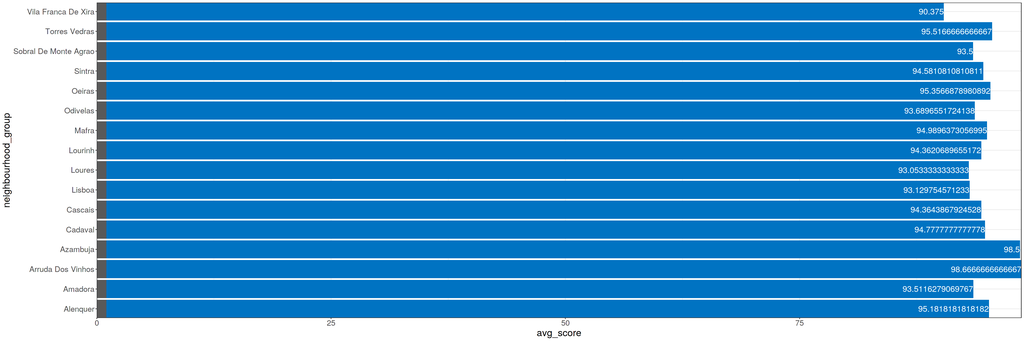

```r
Neighbourhood_group_rating_avg <- listings_df %>%
  filter(number_of_reviews>10) %>%
  group_by(neighbourhood_group) %>%
  summarise(avg_score = mean(review_scores_rating,na.rm=TRUE))

head(Neighbourhood_group_rating_avg)


options(repr.plot.width = 30, repr.plot.height = 10)


ggplot(Neighbourhood_group_rating_avg, aes(x = neighbourhood_group, y = avg_score)) +
  geom_col(fill = "#0073C2FF",stat="dodge") +
  geom_bar(stat="identity",position = "fill")+
  geom_text(aes(label=avg_score), hjust=1, color="white", size=6)+

  coord_flip(expand=FALSE) +

  theme_bw()+
  theme(text = element_text(size=20))
```

## 2.5 Average Prices in the future

See the evolution of the prices in the next months with bookings already made in the future

```r
#use of SQL language to merge datasets calendar , listings_detalis and listings
mydatajoin <- sqldf("select calendar.listing_id,calendar.date,calendar.price,calendar.available,listings_details.accommodates from calendar join listings_details on calendar.listing_id = listings_details.id where listings_details.accommodates=2")

#convert column prices into numeric number
mydatajoin$price=as.numeric(gsub("[\\$,]", "", mydatajoin$price))

head(mydatajoin)
```

A data.frame: 6 × 5

|  | listing_id <int> | date <fct> | price <dbl> | available <fct> | accommodates <int> |
| --- | --- | --- | --- | --- | --- |
| 1 | 28066 | 2019-06-27 | 53 | t | 2 |
| 2 | 28066 | 2019-06-28 | 53 | t | 2 |
| 3 | 28066 | 2019-06-29 | 53 | t | 2 |
| 4 | 28066 | 2019-06-30 | 53 | t | 2 |
| 5 | 28066 | 2019-07-01 | 53 | t | 2 |
| 6 | 28066 | 2019-07-02 | 53 | t | 2 |

A tibble: 6 × 2

| date <date> | avg <dbl> |
| --- | --- |
| 2019-06-26 | 71.41518 |
| 2019-06-27 | 63.26399 |
| 2019-06-28 | 63.58750 |
| 2019-06-29 | 63.88131 |
| 2019-06-30 | 62.49421 |
| 2019-07-01 | 63.43064 |

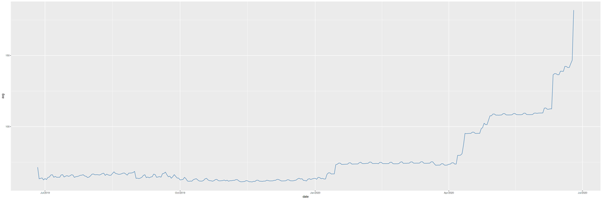

```r
#Calculate average price
#Filters used:
#avaliable=false and accomodates =2
avg_price_future <- mydatajoin %>%
  filter(available=='f') %>%
  group_by(date) %>%
  summarise(avg = mean(price,na.rm=TRUE))

#convert to date format
avg_price_future$date <- as.Date(avg_price_future$date, format="%Y-%m-%d")

head(avg_price_future)

ggplot(avg_price_future, aes(x = date, y = avg)) +
  geom_line(color = "steelblue") +
  scale_x_date(date_labels = "%b/%Y")
```

We can see that prices start to get higher after April 2020

## 2.6 Prices vs Review Ratings

Check if there is any correlation between prices and review ratings

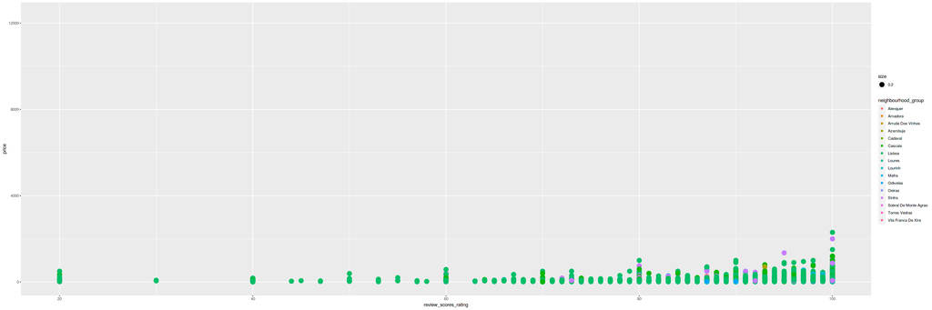

```r
options(repr.plot.width = 30, repr.plot.height = 10)



ggplot(listings_df,aes(size=0.2,color=neighbourhood_group,y = price, x = review_scores_rating)) +
  geom_point()
```

There are some neighbourhood groups like Lisboa and Sintra can get people paying more for better reviews

## 2.7 Find the best Neighbourhood

Analyze which neighbourhood have better review rating with the lowest price possible

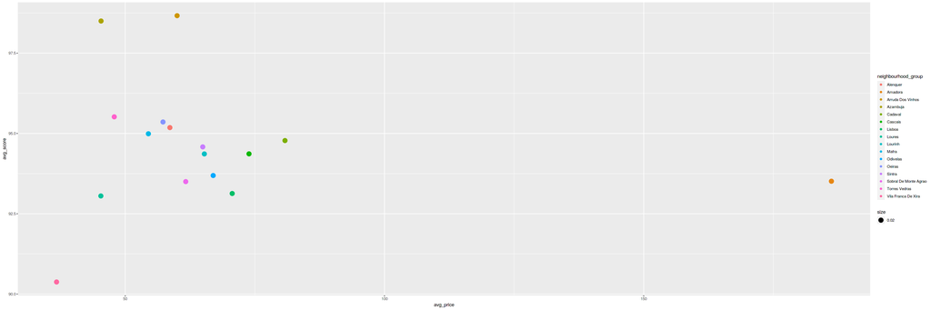

```r
#merge the 2 datasets that contains the average of each variable(rating average and price average)
avg_price_vs_rating_avg<-merge(x = Neighbourhood_group_rating_avg, y = Neighbourhood_group_price_avg, by = "neighbourhood_group", all = TRUE)



options(repr.plot.width = 30, repr.plot.height = 10)



ggplot(avg_price_vs_rating_avg,aes(size=0.02,color=neighbourhood_group,y = avg_score, x = avg_price)) +
  geom_point()
```

Arruada dos Vinhos and Azambuja has the best Price quality analyzing the graph below